# ggplot2-theme

Pawan

2022-12-08

# Themes in ggplot2

The ggplot2 package have different themes. By default it uses the theme_grey (`theme_gray()`), so we don’t need to specify it.

We can adjusted themes by adding an in-build theme from ggplot2.

`theme_gray()` – default ggplot2 theme with a grey background and white gridlines  
`theme_bw()` – dark and light (black and white) ggplot2 theme  
`theme_linedraw()` – uses black lines on white backgrounds only  
`theme_light()` – similar to linedraw() but with grey lines  
`theme_dark()` – lines on a dark background  
`theme_minimal()` – no background annotations  
`theme_classic()` – theme with no grid lines  
`theme_void()` – empty theme with no elements

We can also modify the plot base size by using base_size argument in the theme functions.

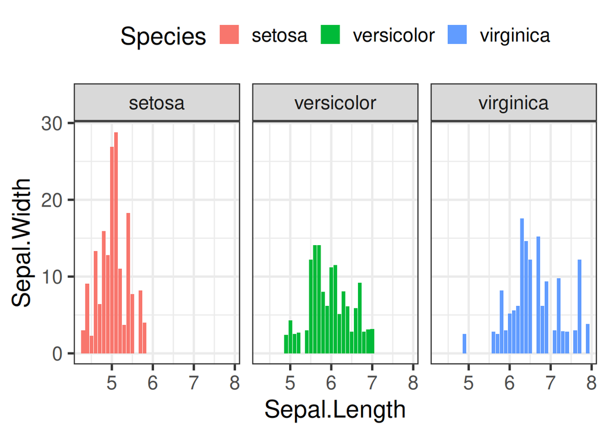

```r
library(ggplot2)

iris->dataset

## Bar plot
ggplot(dataset, aes(x = Sepal.Length, y = Sepal.Width, fill = Species)) +
  geom_bar(stat = "identity", position = "stack") +
  facet_wrap(~Species)->p

## theme_bw()
p+theme_bw(base_size=20) +
  theme(legend.position = "top")->p1
p1
```

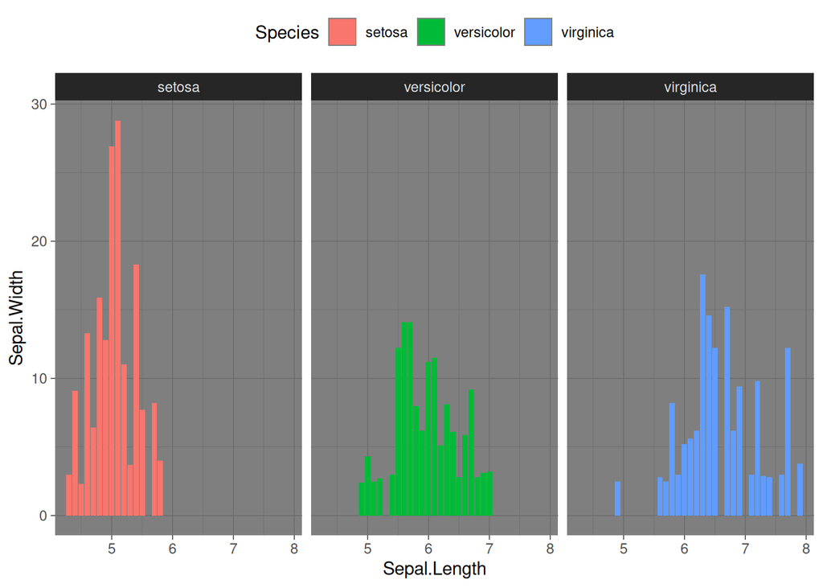

```r
## theme_dark()
p+theme_dark() +
  theme(legend.position = "top")->p2

p2
```

# ggthemes package

The ggthemes package contains several very popular themes.

```
theme_base()         theme_cala()                  theme_clean()
theme_economist()    theme_excel()                 theme_excel_new()
theme_few()          theme_fivethirtyeight()       theme_foundation()
theme_gdocs()        theme_hc()                    theme_igray()
theme_map()          theme_pander()                theme_par()
theme_solarized()    theme_solid()                 theme_stata()
```

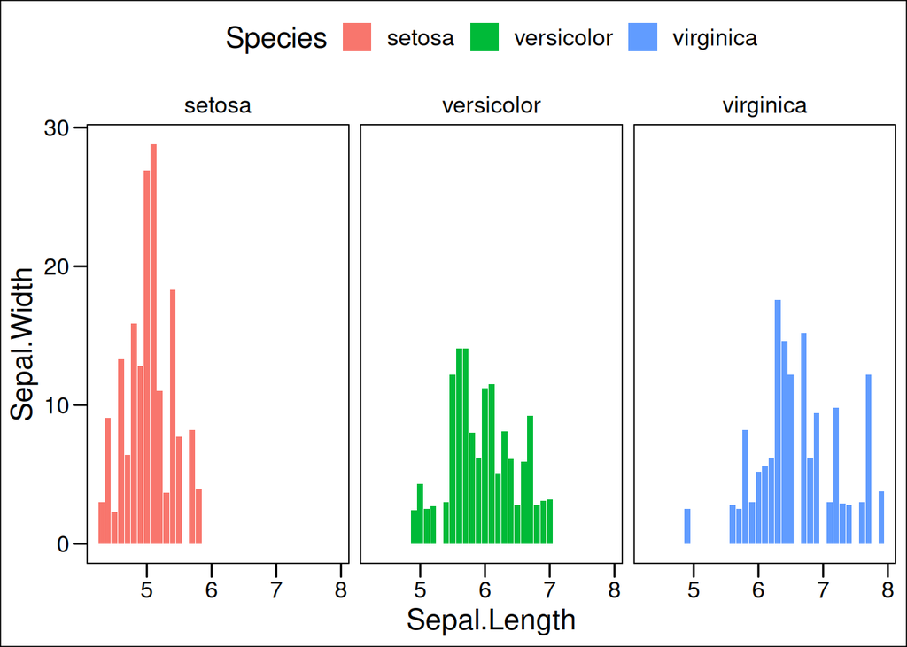

```r
library(ggplot2)
## install.packages("ggthemes")
library(ggthemes)

iris->dataset

## Bar plot
ggplot(dataset, aes(x = Sepal.Length, y = Sepal.Width, fill = Species)) +
  geom_bar(stat = "identity", position = "stack") +
  facet_wrap(~Species)->p

## theme_base()
p+theme_base() +
  theme(legend.position = "top")->p1

## theme_economist()
p+theme_economist() +
  theme(legend.position = "top")->p2
p1
```

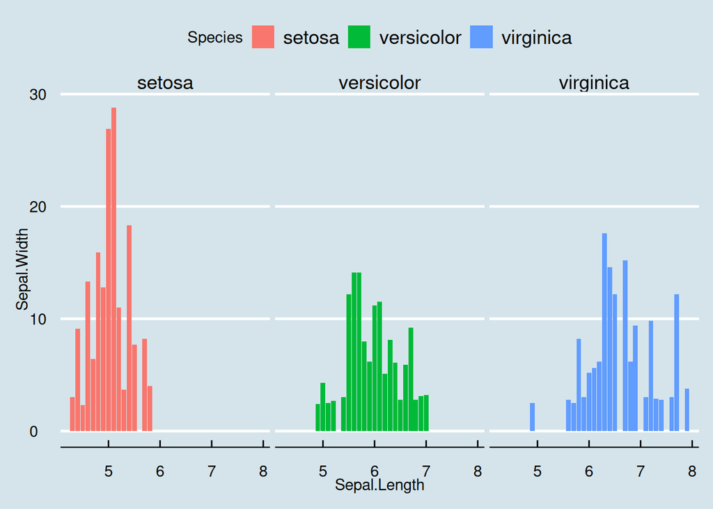

```r
p2
```

# hrbrthemes package

hrbrthemes provides typography-centric themes and theme components for ggplot2. The available themes are listed below,

```
theme_ipsum()              theme_ipsum_es()             theme_ipsum_rc()
theme_ipsum_ps()           theme_ipsum_pub()            theme_ipsum_tw()
theme_ipsum_modern_rc()    theme_ft_rc()
```

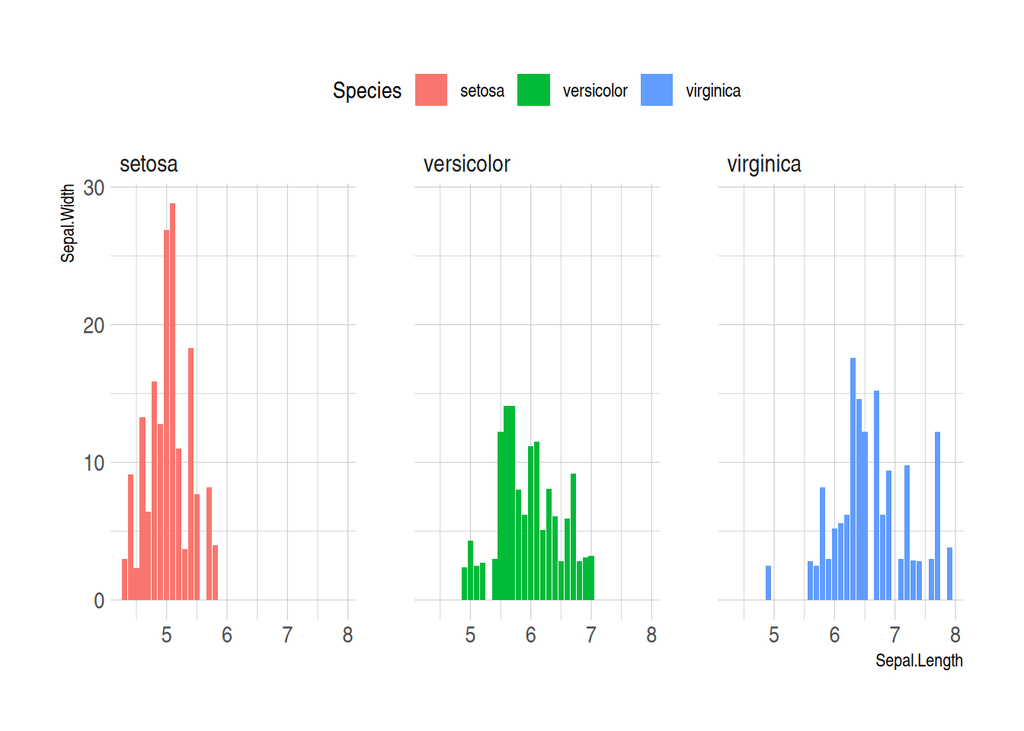

```r
library(ggplot2)
## install.apckages("hrbrthemes")
library(hrbrthemes)
iris->dataset

## Bar plot
ggplot(dataset, aes(x = Sepal.Length, y = Sepal.Width, fill = Species)) +
  geom_bar(stat = "identity", position = "stack") +
  facet_wrap(~Species)->p

p+theme_ipsum()  +
  theme(legend.position = "top")->p
p
```

# ggdark package

ggdark provides the dark mode themes of the ggplot2 themes. This package can convert any theme into a dark theme. The available themes are listed below.

```
dark_theme_gray()         dark_theme_linedraw()          dark_theme_light()          dark_theme_dark()         dark_theme_minimal()           dark_theme_classic()        dark_theme_void()         dark_mode()
```

```r
library(ggplot2)
## install.packages("ggdark")
library(ggdark)

mtcars->dt
cyls <- as.factor(dt$cyl)

ggplot(mtcars, aes(x = mpg, fill = cyls)) +
  geom_density(alpha = 0.7)->p

p+dark_theme_classic() +
  theme(legend.position = "top")->p1
```

```
## Inverted geom defaults of fill and color/colour.
## To change them back, use invert_geom_defaults().
```

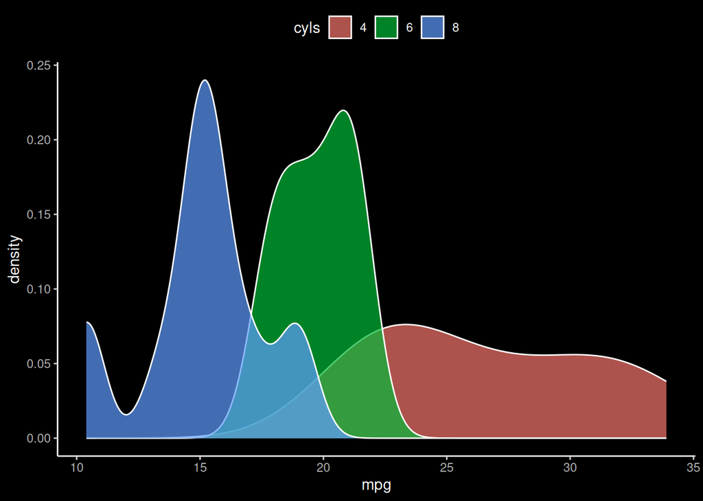

```r
p1
```

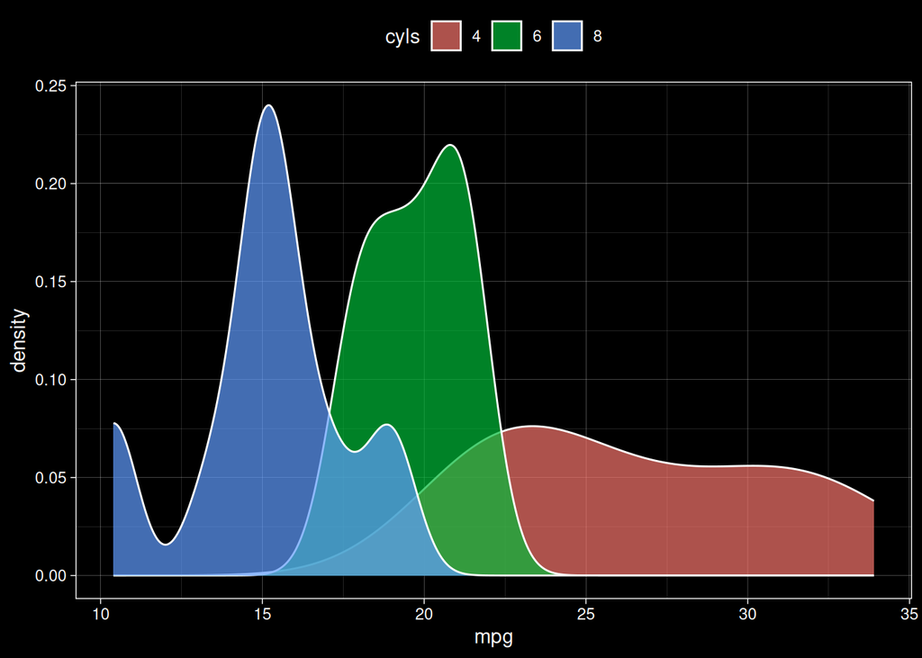

```r
p+dark_theme_linedraw() +
  theme(legend.position = "top")->p2
p2
```

# mdthemes

mdthemes contains all the themes provided by ggplot2, ggthemes, hrbrthemes, and other themes packages. Like as below

```
md_theme_grey()

md_theme_bw()

md_theme_linedraw()

md_theme_light()

md_theme_dark()

md_theme_minimal()

md_theme_classic()
```

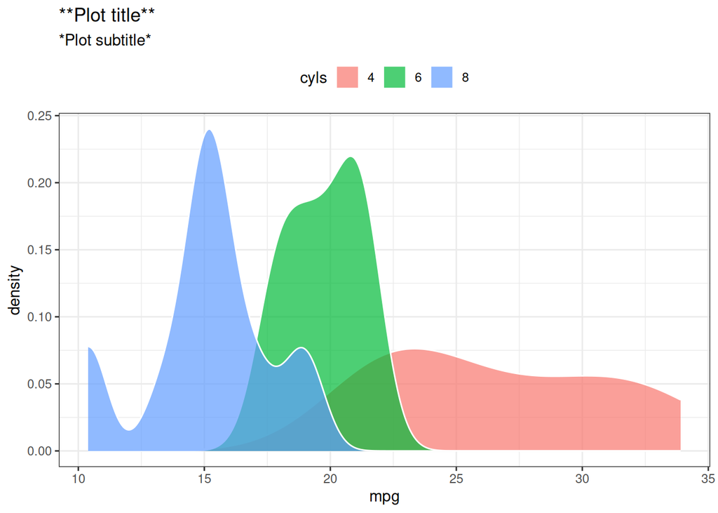

```r
library(ggplot2)
# install.packages("mdthemes")
library(mdthemes)
mtcars->dt
cyls <- as.factor(dt$cyl)

ggplot(dt, aes(x = mpg, fill = cyls)) +
  geom_density(alpha = 0.7)->p
p+labs(title = "**Plot title**",
       subtitle = "*Plot subtitle*")->p

## theme_bw()
p+theme_bw() +
  theme(legend.position = "top")->p1
p1
```

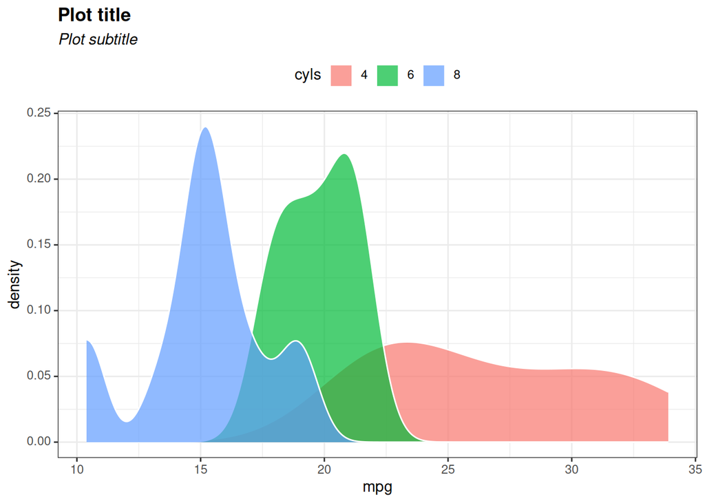

```r
## md_theme_linedraw()
p+md_theme_bw() +
  theme(legend.position = "top")->p2

p2
```